# Data Acquisition

Barkschat Jens, Beyerle Gregor

2021-06-21

## Finding Possible Ticker Symbols

As we’re looking at S&P 500 data and plan to cluster the different companies with regard to their performance (and crisis performance) we’ll try to get as many companies, that have been listed in the S&P 500 and exist to this day.

We take all ticker symbols that have been in the S&P 500 since 1996. We use the tracking data supplied in this [repository](https://github.com/fja05680/sp500).

For all these years we’ll collect all symbols and keep the unique ones for further processing.

```
[1] 488
```

## Check Ticker Symbol Availability

We use the `TTR` package to find out which of those symbols are still commonly available. S&P 500 indizes are usually commonly traded but companies, that do not exist anymore will surely not be listed anymore.

```
Fetching NASDAQ symbols...
Fetching non-NASDAQ symbols...
```

```
[1] 10856
```

If our symbols aren’t available anymore we will throw them out.

```
[1] 274
```

```
  [1] "AAL"   "AAPL"  "ABT"   "ACV"   "ADM"   "ADP"   "ADSK"  "AEE"   "AEP"   "AGC"   "AIG"   "AIT"   "AL"    "ALL"   "AM"
 [16] "AMAT"  "AMD"   "AMGN"  "AMH"   "AMP"   "AN"    "APD"   "AR"    "ARC"   "ARNC"  "ASC"   "ASH"   "ATI"   "AVY"   "AXP"
 [31] "BA"    "BAC"   "BAX"   "BBI"   "BC"    "BCO"   "BDX"   "BEAM"  "BFI"   "BK"    "BLL"   "BMY"   "BNL"   "BR"    "BSX"
 [46] "BUD"   "C"     "CAG"   "CAL"   "CAR"   "CAT"   "CB"    "CBB"   "CCB"   "CCI"   "CCK"   "CEN"   "CG"    "CHRS"  "CI"
 [61] "CL"    "CLX"   "CMA"   "CMCSA" "CMI"   "CNP"   "COMS"  "COP"   "COST"  "CPB"   "CR"    "CSCO"  "CSR"   "CSX"   "CVS"
 [76] "CVX"   "D"     "DD"    "DDS"   "DE"    "DIS"   "DLX"   "DOV"   "DOW"   "DRI"   "DTE"   "DUK"   "DXC"   "EC"    "ECH"
 [91] "ECL"   "ED"    "EFU"   "EIX"   "EMN"   "EMR"   "ENS"   "ETN"   "ETR"   "EXC"   "F"     "FCN"   "FCX"   "FDX"   "FE"
[106] "FL"    "FMC"   "G"     "GD"    "GE"    "GIS"   "GLD"   "GLW"   "GP"    "GPC"   "GPS"   "GRA"   "GRN"   "GT"    "GTE"
[121] "GWW"   "H"     "HAL"   "HAS"   "HCA"   "HD"    "HES"   "HI"    "HIG"   "HLT"   "HON"   "HP"    "HPQ"   "HRB"   "HSY"
[136] "HUM"   "IBM"   "IFF"   "INGR"  "INTC"  "IP"    "IPG"   "IR"    "ITT"   "ITW"   "JCI"   "JNJ"   "JP"    "JPM"   "JWN"
[151] "K"     "KBH"   "KEY"   "KMB"   "KO"    "KR"    "L"     "LB"    "LLY"   "LMT"   "LNC"   "LOW"   "LPX"   "LSI"   "LUB"
[166] "LUV"   "M"     "MAS"   "MAT"   "MCD"   "MCO"   "MD"    "MDP"   "MDT"   "MMC"   "MMM"   "MNR"   "MO"    "MRK"   "MRO"
[181] "MS"    "MSFT"  "MSI"   "MU"    "NAV"   "NC"    "NEE"   "NEM"   "NKE"   "NOC"   "NSC"   "NUE"   "NWL"   "NYT"   "OKE"
[196] "OM"    "ONE"   "ORCL"  "OXY"   "PAC"   "PBI"   "PCAR"  "PCG"   "PCH"   "PD"    "PEG"   "PEP"   "PFE"   "PG"    "PH"
[211] "PHB"   "PHM"   "PKI"   "PLL"   "PNC"   "PPG"   "PPL"   "R"     "RAD"   "ROK"   "RRD"   "RYI"   "S"     "SAF"   "SB"
[226] "SCI"   "SHW"   "SLB"   "SNA"   "SO"    "SPGI"  "SUN"   "SWK"   "SYY"   "T"     "TA"    "TAP"   "TEN"   "TGNA"  "TGT"
[241] "THC"   "THY"   "TJX"   "TKR"   "TRV"   "TX"    "TXN"   "TXT"   "UCC"   "UCL"   "UIS"   "UK"    "UNH"   "UNM"   "UNP"
[256] "USB"   "UST"   "VFC"   "VO"    "VZ"    "WB"    "WBA"   "WEN"   "WFC"   "WHR"   "WLL"   "WMB"   "WMT"   "WOR"   "WY"
[271] "X"     "XEL"   "XOM"   "XRX"
```

## Collect Ticker Data

[output not shown]

[output cut: 222 more lines]

[output not shown]

Because we can’t sensibly impute data for these financial time series we’ll only include symbols for which there are all price data available.

| price.open | price.high | price.low | price.close | volume | price.adjusted | ref.date | ticker | ret.adjusted.prices | ret.closing.prices |
| --- | --- | --- | --- | --- | --- | --- | --- | --- | --- |
| 0.376116 | 0.377232 | 0.357143 | 0.368304 | 952884800 | 0.316706 | 1999-01-04 | AAPL | NA | NA |
| 0.374442 | 0.392299 | 0.370536 | 0.386719 | 1410113600 | 0.332541 | 1999-01-05 | AAPL | 0.0499990527 | 0.0499994570 |
| 0.393973 | 0.393973 | 0.366071 | 0.372768 | 1348569600 | 0.320544 | 1999-01-06 | AAPL | -0.0360767544 | -0.0360752898 |
| 0.377232 | 0.402344 | 0.376116 | 0.401786 | 1429019200 | 0.345497 | 1999-01-07 | AAPL | 0.0778457872 | 0.0778446648 |
| 0.415737 | 0.418527 | 0.392857 | 0.401786 | 678832000 | 0.345497 | 1999-01-08 | AAPL | 0.0000000000 | 0.0000000000 |
| 0.408482 | 0.411272 | 0.400670 | 0.409598 | 560974400 | 0.352214 | 1999-01-11 | AAPL | 0.0194415581 | 0.0194431862 |
| 0.413504 | 0.416295 | 0.393973 | 0.411830 | 820736000 | 0.354134 | 1999-01-12 | AAPL | 0.0054512314 | 0.0054492454 |
| 0.382813 | 0.422433 | 0.377232 | 0.415179 | 1047816000 | 0.357014 | 1999-01-13 | AAPL | 0.0081325148 | 0.0081319962 |
| 0.406250 | 0.410714 | 0.366629 | 0.369420 | 1723859200 | 0.317665 | 1999-01-14 | AAPL | -0.1102169663 | -0.1102151120 |
| 0.373326 | 0.376116 | 0.357143 | 0.368862 | 1006006400 | 0.317186 | 1999-01-15 | AAPL | -0.0015078778 | -0.0015104759 |

[output cut: 990 more lines]

## Collecting Metadata

For analysis purposes it makes sense to collect additional information like the sector and sub-sector of a company.

| Symbol | Name | LastSale | MarketCap | IPOyear | Sector | Industry | Exchange | Test.Issue | Round.Lot.Size | ETF | Market.Category | Financial.Status | Next.Shares | ACT.Symbol | CQS.Symbol | NASDAQ.Symbol |
| --- | --- | --- | --- | --- | --- | --- | --- | --- | --- | --- | --- | --- | --- | --- | --- | --- |
| AAPL | Apple Inc. - Common Stock | NA | NA | NA | NA | NA | NASDAQ | FALSE | 100 | FALSE | NASDAQ Global Select MarketSM | Normal (Default) | NA | NA | NA | AAPL |
| ADP | Automatic Data Processing, Inc. - Common Stock | NA | NA | NA | NA | NA | NASDAQ | FALSE | 100 | FALSE | NASDAQ Global Select MarketSM | Normal (Default) | NA | NA | NA | ADP |
| ADSK | Autodesk, Inc. - Common Stock | NA | NA | NA | NA | NA | NASDAQ | FALSE | 100 | FALSE | NASDAQ Global Select MarketSM | Normal (Default) | NA | NA | NA | ADSK |
| AEP | American Electric Power Company, Inc. - Common Stock | NA | NA | NA | NA | NA | NASDAQ | FALSE | 100 | FALSE | NASDAQ Global Select MarketSM | Normal (Default) | NA | NA | NA | AEP |
| AMAT | Applied Materials, Inc. - Common Stock | NA | NA | NA | NA | NA | NASDAQ | FALSE | 100 | FALSE | NASDAQ Global Select MarketSM | Normal (Default) | NA | NA | NA | AMAT |
| AMD | Advanced Micro Devices, Inc. - Common Stock | NA | NA | NA | NA | NA | NASDAQ | FALSE | 100 | FALSE | NASDAQ Global Select MarketSM | Normal (Default) | NA | NA | NA | AMD |
| AMGN | Amgen Inc. - Common Stock | NA | NA | NA | NA | NA | NASDAQ | FALSE | 100 | FALSE | NASDAQ Global Select MarketSM | Normal (Default) | NA | NA | NA | AMGN |
| BBI | Brickell Biotech, Inc. - Common Stock | NA | NA | NA | NA | NA | NASDAQ | FALSE | 100 | FALSE | NASDAQ Capital Market | Deficient | NA | NA | NA | BBI |
| CAR | Avis Budget Group, Inc. - Common Stock | NA | NA | NA | NA | NA | NASDAQ | FALSE | 100 | FALSE | NASDAQ Global Select MarketSM | Normal (Default) | NA | NA | NA | CAR |
| CMCSA | Comcast Corporation - Class A Common Stock | NA | NA | NA | NA | NA | NASDAQ | FALSE | 100 | FALSE | NASDAQ Global Select MarketSM | Normal (Default) | NA | NA | NA | CMCSA |

[output cut: 206 more lines]

The `SP500_const_info` data frame is unfortunately not always up to date so there is a considerable amount of missing data points for our data set. Still, there is enough data to use in our analysis.

| Symbol | Sector | Subsector |
| --- | --- | --- |
| MMM | Industrials | Industrial Conglomerates |
| ABT | Health Care | Health Care Equipment & Services |
| APD | Materials | Industrial Gases |
| ALL | Financials | Property & Casualty Insurance |
| MO | Consumer Staples | Tobacco |
| AEE | Utilities | MultiUtilities |
| AEP | Utilities | Electric Utilities |
| AXP | Financials | Consumer Finance |
| AIG | Financials | Property & Casualty Insurance |
| AMGN | Health Care | Biotechnology |

[output cut: 164 more lines]

In the end we decided to keep eight attributes in case we need them in further analysis. The most useful of them being the name, the symbol as an identifier, the secotr and the subsector.

| Symbol | Name | Exchange | Round.Lot.Size | Market.Category | Financial.Status | Sector | Subsector |
| --- | --- | --- | --- | --- | --- | --- | --- |
| AAPL | Apple Inc. - Common Stock | NASDAQ | 100 | NASDAQ Global Select MarketSM | Normal (Default) | Information Technology | Computer Hardware |
| ADP | Automatic Data Processing, Inc. - Common Stock | NASDAQ | 100 | NASDAQ Global Select MarketSM | Normal (Default) | Information Technology | Internet Software & Services |
| ADSK | Autodesk, Inc. - Common Stock | NASDAQ | 100 | NASDAQ Global Select MarketSM | Normal (Default) | Information Technology | Application Software |
| AEP | American Electric Power Company, Inc. - Common Stock | NASDAQ | 100 | NASDAQ Global Select MarketSM | Normal (Default) | Utilities | Electric Utilities |
| AMAT | Applied Materials, Inc. - Common Stock | NASDAQ | 100 | NASDAQ Global Select MarketSM | Normal (Default) | Information Technology | Semiconductor Equipment |
| AMD | Advanced Micro Devices, Inc. - Common Stock | NASDAQ | 100 | NASDAQ Global Select MarketSM | Normal (Default) | NA | NA |
| AMGN | Amgen Inc. - Common Stock | NASDAQ | 100 | NASDAQ Global Select MarketSM | Normal (Default) | Health Care | Biotechnology |
| BBI | Brickell Biotech, Inc. - Common Stock | NASDAQ | 100 | NASDAQ Capital Market | Deficient | NA | NA |
| CAR | Avis Budget Group, Inc. - Common Stock | NASDAQ | 100 | NASDAQ Global Select MarketSM | Normal (Default) | NA | NA |
| CMCSA | Comcast Corporation - Class A Common Stock | NASDAQ | 100 | NASDAQ Global Select MarketSM | Normal (Default) | Consumer Discretionary | Broadcasting & Cable TV |

[output cut: 206 more lines]

## Quick Sanity Check

At this point we have complete daily time series for 216 ticker symbols. We can plot the daily closing prices for one symbol (AAPL for Apple) to check if the data we pulled down makes sense.

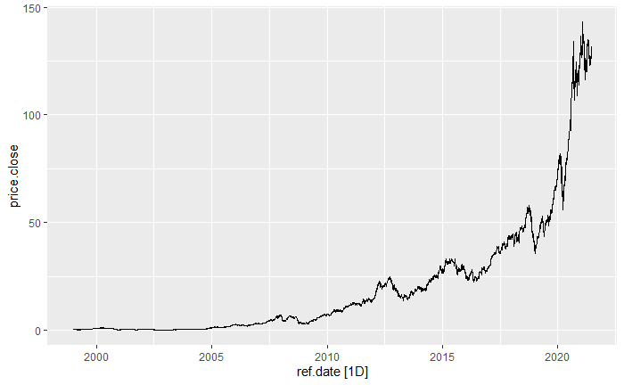

## Persisting The Data

When we’re happy with the data we can save it for later processing.